# Intro To Text Mining

#### How to go beyond the basics?

Suppose we want to make more advanced comparisons. E.g., given a new (third) document, is it more like the first or the second?

We must think of a way of representing our two documents. We want our representation to:

1. Be easy to generate from the raw documents, and be easy to work with
2. Highlight important aspects of the documents, and suppress unimportant aspects

Think we need some fancy representation? Think again! We pretty much already have what we need

### Document-term matrix

This is like what we’re already doing! Key difference is that we must calculate word counts for words that appear across **all documents**

```r
# Let's set up our third document, the query document
query.text = "Make America great again."
query.words = strsplit(query.text, split=" ")[[1]]
query.wordtab = table(tolower(query.words))

# Let's get all the words, then just consider the unique ones, sorted alphabetically
all.words = c(names(trump.wordtab), names(clinton.wordtab), names(query.wordtab))
all.words.unique = sort(unique(all.words))
nW = length(all.words.unique)
```

The document-term-matrix ( that is $(\text{# of documents}) \times (\text{# of unique words})$, or for us, 3 x 2653): each row contains the word counts for one document

```r
dt.mat = matrix(0, 3, length(all.words.unique))
rownames(dt.mat) = c("Trump", "Clinton", "Query")
colnames(dt.mat) = all.words.unique
dt.mat[1, names(trump.wordtab)] = trump.wordtab
dt.mat[2, names(clinton.wordtab)] = clinton.wordtab
dt.mat[3, names(query.wordtab)] = query.wordtab
dt.mat[, 1:10]
```

```
##         'i - "let "midnight "morning "planting "we $150 $19 $2
## Trump    1 0    0         0        0         0   0    1   1  1
## Clinton  0 1    1         1        1         1   1    0   0  0
## Query    0 0    0         0        0         0   0    0   0  0
```

#### Computing word count differences

Which words had the biggest (absolute) differences in counts between our two documents?

```r
dt.diff = dt.mat[1,] - dt.mat[2,]
dt.diff[sample(length(dt.diff), 5)]
```

```
##    security.      better,    entirely. uncontrolled    judgment,
##           -2           -1            1            1           -1
```

```r
dt.diff.abs.sorted = sort(abs(dt.diff), decreasing=TRUE)
dt.diff.abs.sorted[1:20] # Top 20 biggest absolute differences
```

```
##     and     you       a    will      to      we      of      he    have
##      66      58      52      49      42      37      31      30      29
##  people      it    just     our     not believe    what      as    been
##      23      22      21      19      18      17      17      16      15
##  should      am
##      15      14
```

Now we don’t know the direction though, e.g., who said “believe” more?

Reminder: `order()`

```r
inds.sorted = order(abs(dt.diff), decreasing=TRUE)
dt.diff[inds.sorted[1:20]] # Top 20 biggest differences, with signs
```

```
##     and     you       a    will      to      we      of      he    have
##     -66     -58     -52      49     -42     -37      31     -30      29
##  people      it    just     our     not believe    what      as    been
##     -23     -22     -21      19     -18     -17     -17     -16      15
##  should      am
##     -15      14
```

#### Computing correlations

Which of our two documents is “closest” to the query? Depends on how we define “closest”; but one reasonable way is to use **correlation**, easily computed with the `cor()` function

```r
cor(dt.mat[1,], dt.mat[3,])
```

```
## [1] 0.0525135
```

```r
cor(dt.mat[2,], dt.mat[3,])
```

```
## [1] 0.03742041
```

### Bag of foolishness

[figure not shown]

- “A fool with a tool is still a fool” - “A fool without a tool is still a fool”
- “I am against higher taxes and for deregulation.” - “I am for higher taxes and against deregulation.”
- “Is broccoli bad for health?” - “Broccoli is bad for health.”
- “How to teach an old dog new tricks.” - “How an old dog teaches new tricks.”

### package tm

```r
mystopwords <- c("and", "for", "in", "is", "it", "not", "the", "to")
trump.lines = removeWords(tolower(trump.lines), mystopwords)
clinton.lines = removeWords(clinton.lines, mystopwords)
#better:

clinton.lines = removeWords(tolower(clinton.lines), stopwords("english"))
```

#### Whitespace elimination

```r
stripWhitespace("Together,   we   will   lead.  ")
```

```
## [1] "Together, we will lead. "
```

#### Everything is a corpus

```r
reut21578 <- system.file("texts", "crude", package = "tm")
reuters <- VCorpus(DirSource(reut21578),
                   readerControl = list(reader = readReut21578XMLasPlain))

inspect(reuters[[2]])
```

```
## <<PlainTextDocument>>
## Metadata:  16
## Content:  chars: 2634
##
## OPEC may be forced to meet before a
## scheduled June session to readdress its production cutting
## agreement if the organization wants to halt the current slide
## in oil prices, oil industry analysts said.
##     "The movement to higher oil prices was never to be as easy
## as OPEC thought. They may need an emergency meeting to sort out
## the problems," said Daniel Yergin, director of Cambridge Energy
## Research Associates, CERA.
##     Analysts and oil industry sources said the problem OPEC
## faces is excess oil supply in world oil markets.
##     "OPEC's problem is not a price problem but a production
## issue and must be addressed in that way," said Paul Mlotok, oil
## analyst with Salomon Brothers Inc.
##     He said the market's earlier optimism about OPEC and its
## ability to keep production under control have given way to a
## pessimistic outlook that the organization must address soon if
## it wishes to regain the initiative in oil prices.
##     But some other analysts were uncertain that even an
## emergency meeting would address the problem of OPEC production
## above the 15.8 mln bpd quota set last December.
##     "OPEC has to learn that in a buyers market you cannot have
## deemed quotas, fixed prices and set differentials," said the
## regional manager for one of the major oil companies who spoke
## on condition that he not be named. "The market is now trying to
## teach them that lesson again," he added.
##     David T. Mizrahi, editor of Mideast reports, expects OPEC
## to meet before June, although not immediately. However, he is
## not optimistic that OPEC can address its principal problems.
##     "They will not meet now as they try to take advantage of the
## winter demand to sell their oil, but in late March and April
## when demand slackens," Mizrahi said.
##     But Mizrahi said that OPEC is unlikely to do anything more
## than reiterate its agreement to keep output at 15.8 mln bpd."
##     Analysts said that the next two months will be critical for
## OPEC's ability to hold together prices and output.
##     "OPEC must hold to its pact for the next six to eight weeks
## since buyers will come back into the market then," said Dillard
## Spriggs of Petroleum Analysis Ltd in New York.
##     But Bijan Moussavar-Rahmani of Harvard University's Energy
## and Environment Policy Center said that the demand for OPEC oil
## has been rising through the first quarter and this may have
## prompted excesses in its production.
##     "Demand for their (OPEC) oil is clearly above 15.8 mln bpd
## and is probably closer to 17 mln bpd or higher now so what we
## are seeing characterized as cheating is OPEC meeting this
## demand through current production," he told Reuters in a
## telephone interview.
##  Reuter
```

```r
#manipulate:
reuters <- tm_map(reuters, stripWhitespace)
reuters <- tm_map(reuters, content_transformer(tolower))
reuters <- tm_map(reuters, removeWords, stopwords("english"))
```

```r
dtm <- DocumentTermMatrix(reuters,
                          control = list(removePunctuation = TRUE,
                                         stopwords = TRUE))
inspect(dtm[5:10, 740:743])
```

```
## <<DocumentTermMatrix (documents: 6, terms: 4)>>
## Non-/sparse entries: 3/21
## Sparsity           : 88%
## Maximal term length: 9
## Weighting          : term frequency (tf)
## Sample             :
##      Terms
## Docs  reduced reduction reference referring
##   211       0         0         0         0
##   236       0         0         1         2
##   237       2         0         0         0
##   242       0         0         0         0
##   246       0         0         0         0
##   248       0         0         0         0
```

If we want to find associations (i.e., terms which correlate) with at least $0.8$ correlation for the term opec, then we use findAssocs():

```r
findAssocs(dtm, "opec", 0.8)
```

```
## $opec
##        158   analysts     buyers  emergency        oil    meeting
##       0.88       0.87       0.87       0.87       0.87       0.83
## production      named
##       0.82       0.81
```

Term-document matrices tend to get very big already for normal sized data sets. Therefore we provide a method to remove sparse terms, i.e., terms occurring only in very few documents. Normally, this reduces the matrix dramatically; sometimes without losing significant relations inherent to the matrix:

```r
inspect(removeSparseTerms(dtm, 0.4))
```

```
## <<DocumentTermMatrix (documents: 20, terms: 4)>>
## Non-/sparse entries: 75/5
## Sparsity           : 6%
## Maximal term length: 6
## Weighting          : term frequency (tf)
## Sample             :
##      Terms
## Docs  oil prices reuter said
##   127   5      3      1    3
##   144  12      5      1   11
##   236   7      5      1   10
##   246   5      1      1    5
##   248   9      9      1    7
##   273   5      5      1    8
##   352   5      5      1    2
##   502   5      2      1    2
##   543   3      2      1    4
##   704   3      3      1    4
```

Finally, some fun visualization:

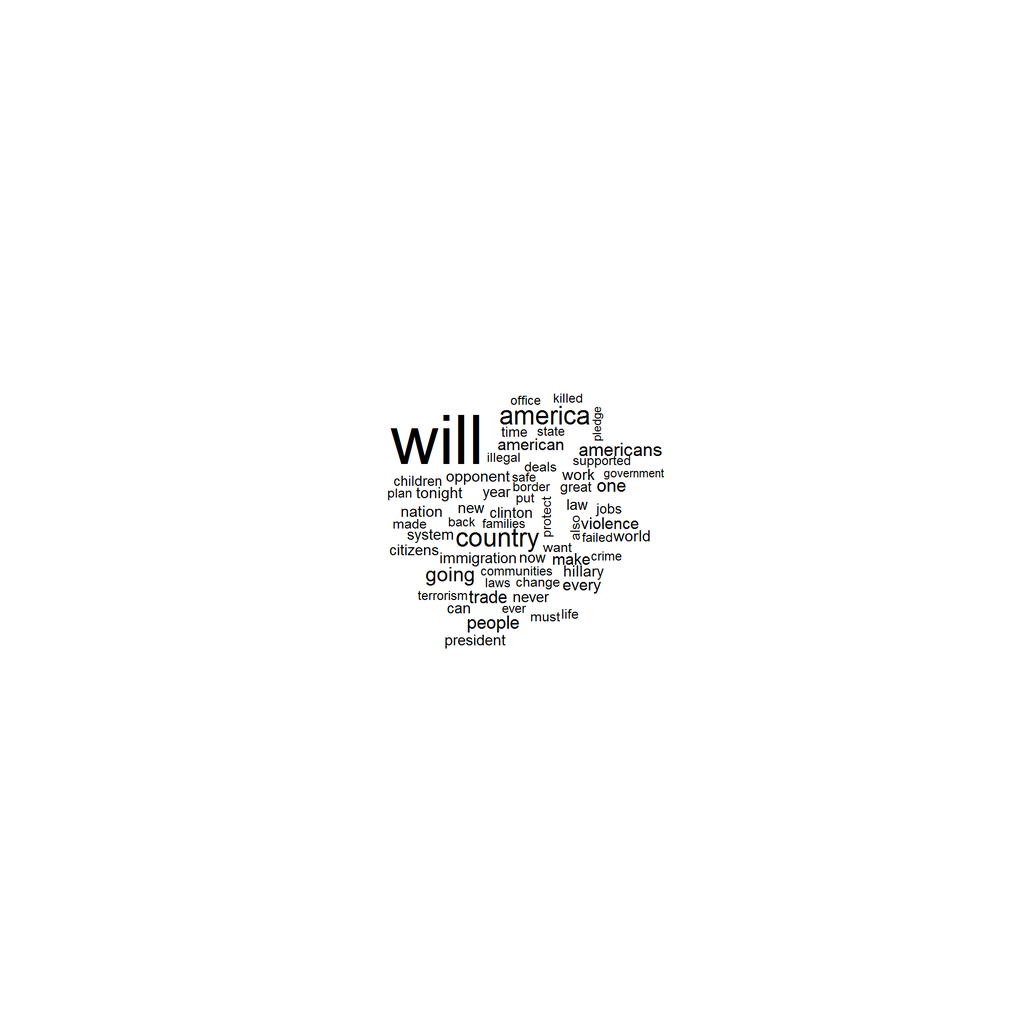

```r
wordcloud(trump.lines,max.words=60)
```

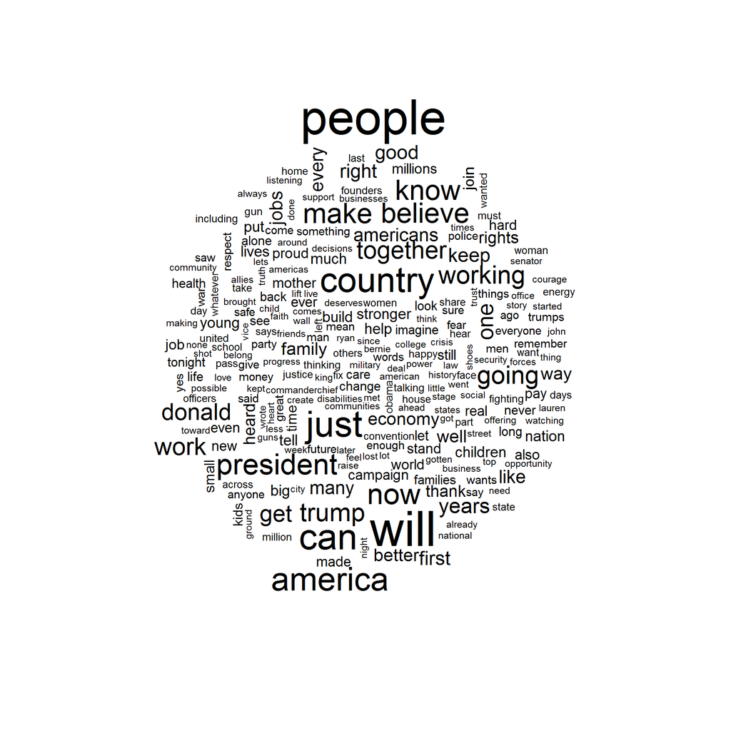

```r
wordcloud(clinton.lines)
```

### package tidytext

#### First The gutenbergr package

Let’s introduce the gutenbergr package. The gutenbergr package provides access to the public domain works from the [Project Gutenberg](https://www.gutenberg.org/) collection. We will look at some science fiction and fantasy novels by H.G. Wells, who lived in the late 19th and early 20th centuries. Let’s get [*The Time Machine*](https://www.gutenberg.org/ebooks/35), [*The War of the Worlds*](https://www.gutenberg.org/ebooks/36), [*The Invisible Man*](https://www.gutenberg.org/ebooks/5230), and [*The Island of Doctor Moreau*](https://www.gutenberg.org/ebooks/159).

```r
#hgwells <- gutenberg_download(c(35, 36, 5230, 159))
#save(hgwells, file="data/hgwells.rda")
load("data/hgwells.rda")
```

Using tidy data principles is a powerful way to make handling data easier and more effective, and this is no less true when it comes to dealing with text. tidy data has a specific structure:

- Each variable is a column
- Each observation is a row
- Each type of observational unit is a table

We thus define the tidy text format as being **a table with one-token-per-row.** A token is a meaningful unit of text, such as a word, that we are interested in using for analysis, and tokenization is the process of splitting text into tokens. This one-token-per-row structure is in contrast to the ways text is often stored in current analyses, perhaps as strings or in a document-term matrix. For tidy text mining, the **token** that is stored in each row is most often a single word, but can also be an n-gram, sentence, or paragraph. In the tidytext package, we provide functionality to tokenize by commonly used units of text like these and convert to a one-term-per-row format.

Tidy data sets allow manipulation with a standard set of “tidy” tools, including popular packages such as dplyr, tidyr, ggplot2 , and broom . By keeping the input and output in tidy tables, users can transition fluidly between these packages. We’ve found these tidy tools extend naturally to many text analyses and explorations.

A key function is **unnest_tokens()**:

```r
tidy_hgwells <- hgwells %>%
  unnest_tokens(word, text) %>%
  anti_join(stop_words)
```

After using `unnest_tokens`, we’ve split each row so that there is one token (word) in each row of the new data frame; the default tokenization in `unnest_tokens()` is for single words, as shown here. Also notice:

- Other columns, such as the line number each word came from, are retained.
- Punctuation has been stripped.
- By default, `unnest_tokens()` converts the tokens to lowercase, which makes them easier to compare or combine with other datasets. (Use the `to_lower = FALSE` argument to turn off this behavior).

Just for kicks, what are the most common words in these novels of H.G. Wells?

```r
tidy_hgwells %>%
  count(word, sort = TRUE)
```

```
## # A tibble: 11,769 x 2
##    word       n
##    <chr>  <int>
##  1 time     454
##  2 people   302
##  3 door     260
##  4 heard    249
##  5 black    232
##  6 stood    229
##  7 white    222
##  8 hand     218
##  9 kemp     213
## 10 eyes     210
## # ... with 11,759 more rows
```

Now let’s get some well-known works of the BrontÃ« sisters, whose lives overlapped with Jane Austen’s somewhat but who wrote in a rather different style. Let’s get [*Jane Eyre*](https://www.gutenberg.org/ebooks/1260), [*Wuthering Heights*](https://www.gutenberg.org/ebooks/768), [*The Tenant of Wildfell Hall*](https://www.gutenberg.org/ebooks/969), [*Villette*](https://www.gutenberg.org/ebooks/9182), and [*Agnes Grey*](https://www.gutenberg.org/ebooks/767). We will again use the Project Gutenberg ID numbers for each novel and access the texts using `gutenberg_download()`.

```r
bronte <- gutenberg_download(c(1260, 768, 969, 9182, 767))
save(bronte, file="data/bronte.rda")
```

```r
tidy_bronte <- bronte %>%
  unnest_tokens(word, text) %>%
  anti_join(stop_words)
```

What are the most common words in these novels of the Bronte sisters?

```r
tidy_bronte %>%
  count(word, sort = TRUE)
```

```
## # A tibble: 23,050 x 2
##    word       n
##    <chr>  <int>
##  1 time    1065
##  2 miss     855
##  3 day      827
##  4 hand     768
##  5 eyes     713
##  6 night    647
##  7 heart    638
##  8 looked   602
##  9 door     592
## 10 half     586
## # ... with 23,040 more rows
```

Interesting that “time”, “eyes”, and “hand” are in the top 10 for both H.G. Wells and the Bronte sisters.

#### Tidy DocumentTermMatrix

1. By hand: calculate the frequency for each word for the works of the Bronte sisters, and H.G. Wells by binding the data frames together.

```r
frequency <- bind_rows(mutate(tidy_bronte, author = "Bronte Sisters"),
                       mutate(tidy_hgwells, author = "H.G. Wells") ) %>%
  mutate(word = str_extract(word, "[a-z']+")) %>%
  count(gutenberg_id, word)


frequency
```

```
## # A tibble: 71,964 x 3
##    gutenberg_id word             n
##           <int> <chr>        <int>
##  1           35 a                1
##  2           35 abandon          1
##  3           35 abandoned        1
##  4           35 abnormally       1
##  5           35 abominable       2
##  6           35 abominations     1
##  7           35 abruptly         4
##  8           35 absence          4
##  9           35 absent           1
## 10           35 absolute         7
## # ... with 71,954 more rows
```

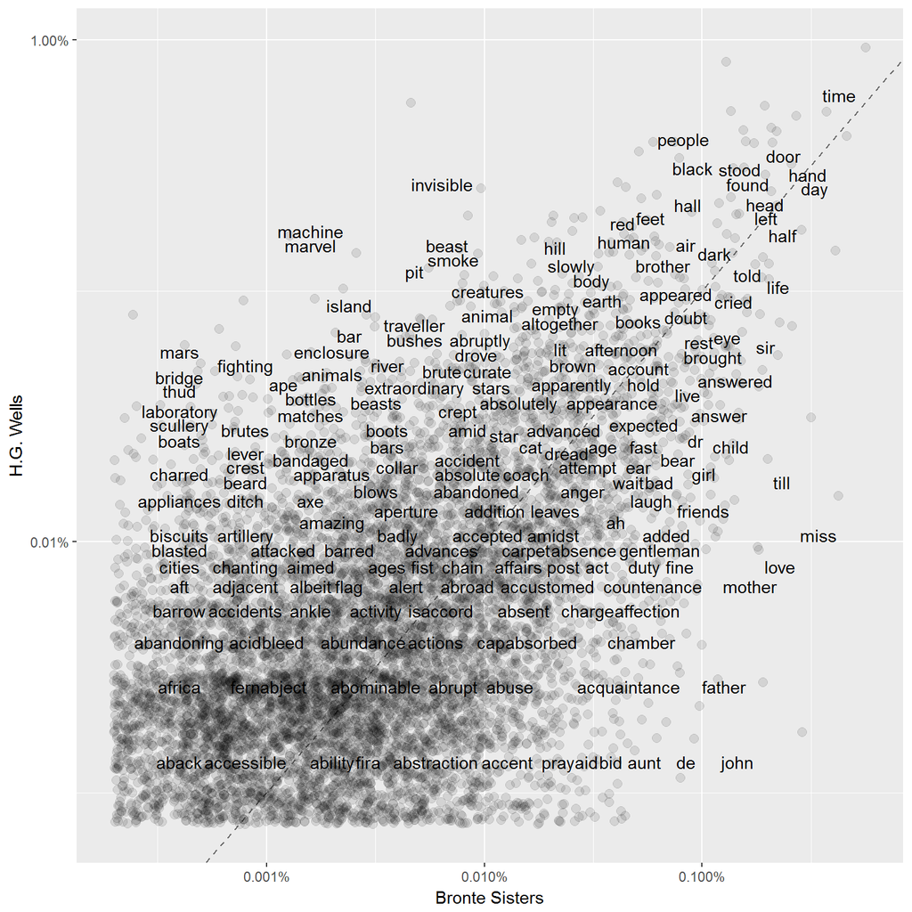

```r
frequency2Plot <- bind_rows(mutate(tidy_bronte, author = "Bronte Sisters"),
              mutate(tidy_hgwells, author = "H.G. Wells") ) %>%
  mutate(word = str_extract(word, "[a-z']+")) %>%
  count(author, word)  %>% group_by(author) %>%
  mutate(proportion = n / sum(n)) %>%
  select(-n) %>%
  spread(author, proportion)
#%>% gather(author, proportion, `Bronte Sisters`:`H.G. Wells`)


# expect a warning about rows with missing values being removed
ggplot(frequency2Plot, aes(x = `Bronte Sisters`, y = `H.G. Wells`)) +
  geom_abline(color = "gray40", lty = 2) +
  geom_jitter(alpha = 0.1, size = 2.5, width = 0.3, height = 0.3) +
  geom_text(aes(label = word), check_overlap = TRUE, vjust = 1.5) +
  scale_x_log10(labels = percent_format()) +
  scale_y_log10(labels = percent_format()) +
  scale_color_gradient(limits = c(0, 0.001), low = "darkslategray4", high = "gray75")
```

2. The tm way

```r
bronteLong = tapply(bronte$text, bronte$gutenberg_id, paste0, collapse=" ")
hgwellsLong = tapply(hgwells$text, hgwells$gutenberg_id, paste0, collapse=" ")
AllTexts = tolower(c(bronteLong, hgwellsLong))

GutCorp = SimpleCorpus(VectorSource(AllTexts))

dtm = DocumentTermMatrix(GutCorp, control = list(removePunctuation = TRUE, stopwords = TRUE))
inspect(dtm[1:9, 1:20])
```

```
## <<DocumentTermMatrix (documents: 9, terms: 20)>>
## Non-/sparse entries: 92/88
## Sparsity           : 49%
## Maximal term length: 10
## Weighting          : term frequency (tf)
## Sample             :
##       Terms
## Docs   abhorrence ability able abode abroad abruptness absence absent
##   1260          0       0   23     8      4          1      14      9
##   159           1       0    4     0      0          1       0      1
##   35            0       0    3     0      0          0       4      1
##   36            0       1   16     0      1          0       3      2
##   5230          0       0    5     0      4          0       0      0
##   767           1       2   21     9      3          2       3      1
##   768           1       0   16     7      2          0      22      7
##   9182          2       2   16     5      8          2      19     10
##   969           6       1   35     8      4          1      14     11
##       Terms
## Docs   absolute absorbed
##   1260        6       11
##   159         2        1
##   35          7        1
##   36          5        0
##   5230        0        1
##   767         2        3
##   768         2       10
##   9182        2       11
##   969         9       11
```

3. The tidytext way:

```r
myTFIDF <- frequency %>% bind_tf_idf(word, gutenberg_id, n)
library(tidyr)

tmp <-  myTFIDF %>% select(gutenberg_id,word,tf_idf) %>% spread(word,tf_idf, fill = 0)
```

### Clustering of text

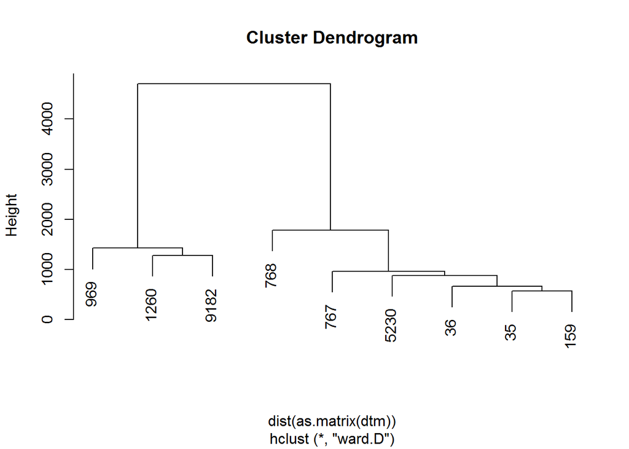

```r
hc <- hclust(dist(as.matrix(dtm)), method = "ward")

plot(hc)
```

#### Exercises

- Try different linkages and count transformations

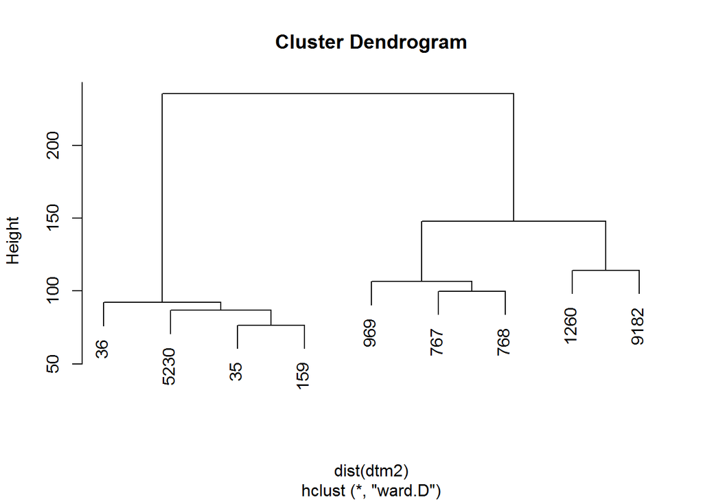

```r
dtm2 = sqrt(as.matrix(dtm))
dtm2 = log(as.matrix(dtm)+1)

hcWard <- hclust(dist(dtm2), method = "ward")
plot(hcWard)
```

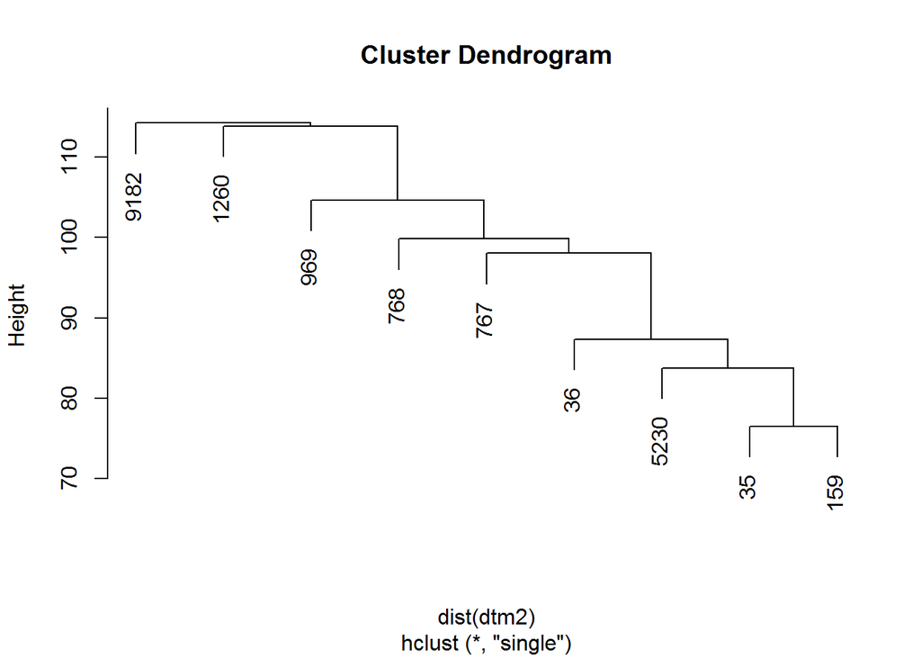

```r
hcSingle <- hclust(dist(dtm2), method = "single")
plot(hcSingle)
```

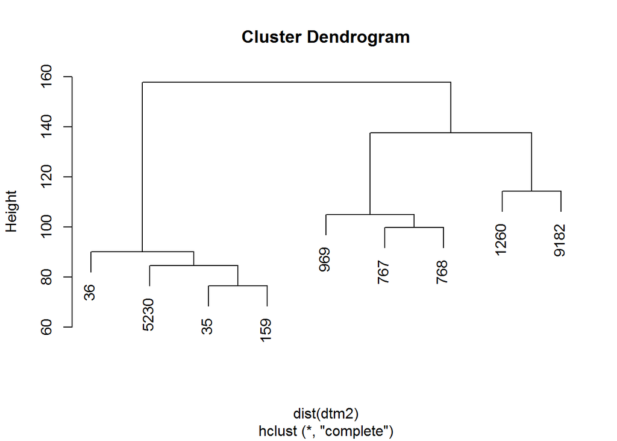

```r
hcComplete <- hclust(dist(dtm2), method = "complete")
plot(hcComplete)
```

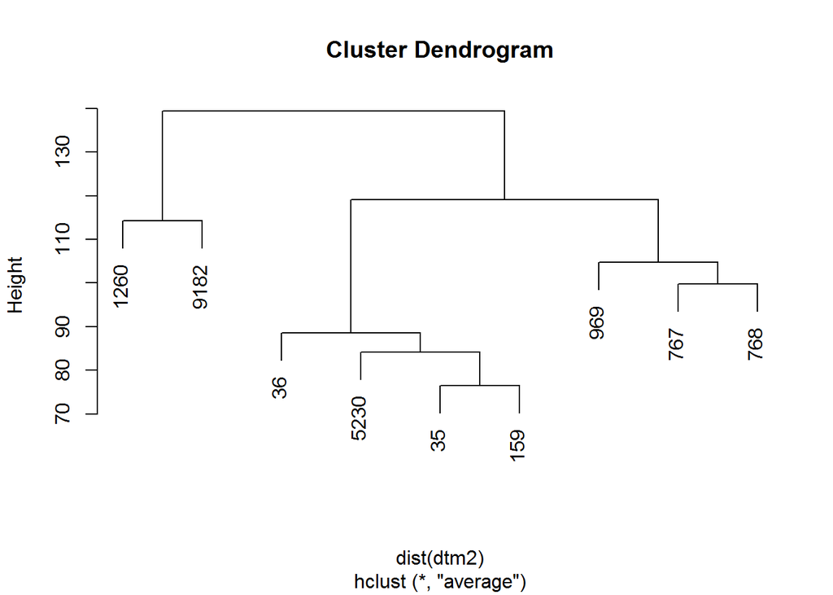

```r
hcAvg <- hclust(dist(dtm2), method = "average")
plot(hcAvg)
```

- Find out why some Bronte books were classified as Wells material.
- What about k-means

```r
BookClusters = kmeans(dtm2, 2)
#BookClusters
```

- Find the optimum number of clusters

### Further Topics

- tf-idf
- n-grams
- Sentiment Analysis
- Prediction

### IDF weighting

How well does our bag-of-words model meet our two goals: 1. easy to set up and use, 2. helpful at teasing out important aspects, and muting unimportant ones?

Not so strong on the second goal (recall the word count differences). But an extension called **inverse-document-frequency** or IDF weighting can help a lot with this

Helps when we have many documents in our collection (also called our corpus). Suppose we have $D$ documents total. IDF weighting works as follows: e.g., the word count
$$(\text{# of times Trump said great})$$
becomes the weighted word count
$$(\text{# of times Trump said great}) \times
\log\bigg(\frac{D}{\text{# of documents with word great}}\bigg)$$
(Note: you’ll see this as TF-IDF, where the TF stands for **term-frequency**)

So when all documents contain the word in question, the weight is zero. Better to have a large corpus, say $D$ in the hundreds or thousands, not $D=2$ like us

```r
bronte_tfIDF = DocumentTermMatrix(GutCorp,
                                  control = list(removePunctuation = TRUE, stopwords = TRUE,
                                                 weighting = weightTfIdf))
inspect(bronte_tfIDF[1:9, 1:20])
```

```
## <<DocumentTermMatrix (documents: 9, terms: 20)>>
## Non-/sparse entries: 83/97
## Sparsity           : 54%
## Maximal term length: 10
## Weighting          : term frequency - inverse document frequency (normalized) (tf-idf)
## Sample             :
##       Terms
## Docs            1st        aback   abhorrence    abilities      ability
##   1260 0.000000e+00 0.000000e+00 0.000000e+00 2.480226e-05 0.000000e+00
##   159  0.000000e+00 0.000000e+00 3.981767e-05 0.000000e+00 0.000000e+00
##   35   0.000000e+00 0.000000e+00 0.000000e+00 0.000000e+00 0.000000e+00
##   36   0.000000e+00 0.000000e+00 0.000000e+00 0.000000e+00 3.937418e-05
##   5230 0.000000e+00 8.920555e-05 0.000000e+00 0.000000e+00 0.000000e+00
##   767  7.088015e-05 7.088015e-05 2.769964e-05 1.417603e-04 7.643072e-05
##   768  0.000000e+00 0.000000e+00 1.569028e-05 0.000000e+00 0.000000e+00
##   9182 0.000000e+00 0.000000e+00 1.779730e-05 0.000000e+00 2.455375e-05
##   969  8.602279e-05 0.000000e+00 6.723464e-05 0.000000e+00 1.545986e-05
##       Terms
## Docs          abode       abroad      absence     absolute     absorbed
##   1260 7.754089e-05 1.657672e-05 5.801851e-05 1.165347e-05 2.136469e-05
##   159  0.000000e+00 0.000000e+00 0.000000e+00 1.595765e-05 7.978823e-06
##   35   0.000000e+00 0.000000e+00 9.374792e-05 7.688914e-05 1.098416e-05
##   36   0.000000e+00 1.220241e-05 3.660722e-05 2.859439e-05 0.000000e+00
##   5230 0.000000e+00 5.962098e-05 0.000000e+00 0.000000e+00 6.985612e-06
##   767  2.492968e-04 3.552983e-05 3.552983e-05 1.110113e-05 1.665170e-05
##   768  1.098320e-04 1.341709e-05 1.475880e-04 6.288162e-06 3.144081e-05
##   9182 4.449325e-05 3.043770e-05 7.228954e-05 3.566294e-06 1.961462e-05
##   969  8.964619e-05 1.916459e-05 6.707606e-05 2.020912e-05 2.470003e-05
```

```r
book_words <- tidy_bronte %>% count(gutenberg_id, word, sort = TRUE) %>%   ungroup()

book_words
```

```
## # A tibble: 51,757 x 3
##    gutenberg_id word           n
##           <int> <chr>      <int>
##  1          768 heathcliff   421
##  2          768 linton       346
##  3         1260 jane         342
##  4          768 catherine    336
##  5         9182 madame       331
##  6         1260 rochester    317
##  7         1260 sir          315
##  8         1260 miss         310
##  9          969 time         304
## 10         9182 day          249
## # ... with 51,747 more rows
```

```r
bronte_tfIDF <- book_words %>%
  bind_tf_idf(word, gutenberg_id, n)

bronte_tfIDF
```

[output not shown]